# R Notebook

Fixed Effect models and First Difference models are similar to the extent that both deal with the unobserved heterogeneity by trying to eliminate it.

They’re also similar to the extent that they atempt to eliminate the unobserved heterogeneity using simple algebraic manipulations, rather than coming up with a new estimation technique, as is the case with Random Effects.

Fixed Effects models (FE) eliminates the unobserved heterogeneity by subtracting each observation from the historical value of that observation.

First Difference models (FD) eliminates the unobserved heterogeneity by looking at changes relative to the previous period.

Both eliminate the unobserved heterogeneity by performing a subtraction. The difference between them lies in what is being subtracted. In FE, it is the historical average of each entity. In FD, it is the corresponding quantity in the previous time period.

Similar as these two techniques may be, they have a very important difference: FE doesn’t affect the true model’s residuals, whereas FD does.

The residuals of the FD model is the change between residuals in successive time periods.

Interestingly, if residuals are independent in the true model, they’re change is *not* independent. In class, we’ve shown mathematicallty that if the correlation in the FE is zero, then the correlation in the FD is -0.5. But mathematical proofs are boring. Let’s see it in action:

```r
set.seed(0)
e <- rnorm(1e4) #independent errors
delta_e <- diff(e) #change in errors
acf(delta_e, plot=FALSE)[1] #serial correlation of change in errors for successive time periods
```

```
Autocorrelations of series ‘delta_e’, by lag

     1
-0.506
```

In order for the FD residuals to be independent, errors in the true model (and in the FE) must follow a **random walk**.

Let’s look at an example with real data.

```r
library(AER)
data("OECDGas")
head(OECDGas)
```

|  | country | year | gas | income | price | cars |
| --- | --- | --- | --- | --- | --- | --- |
| 1 | Austria | 1960 | 4.173244 | -6.474277 | -0.3345476 | -9.766840 |
| 2 | Austria | 1961 | 4.100989 | -6.426006 | -0.3513276 | -9.608622 |
| 3 | Austria | 1962 | 4.073177 | -6.407308 | -0.3795177 | -9.457257 |
| 4 | Austria | 1963 | 4.059509 | -6.370679 | -0.4142514 | -9.343155 |
| 5 | Austria | 1964 | 4.037689 | -6.322247 | -0.4453354 | -9.237739 |
| 6 | Austria | 1965 | 4.033983 | -6.294668 | -0.4970607 | -9.123903 |

We wish to see how gas price (`price`) affects its consumption (`gas`) when controlled by income and by the number of cars.

Are there any unobserved heterogeneities we should be aware of?

```r
library(plm)
plmtest(gas ~ price + income + cars, data = OECDGas, type = "bp")
```

```
    Lagrange Multiplier Test -
    (Breusch-Pagan) for balanced panels

data:  gas ~ price + income + cars
chisq = 1465.6, df = 1, p-value <
2.2e-16
alternative hypothesis: significant effects
```

Yes we do! Ok, next question: should we run random effects or fixed effects?

```r
phtest(gas ~ price + income + cars, data = OECDGas)
```

```
    Hausman Test

data:  gas ~ price + income + cars
chisq = 302.8, df = 3, p-value <
2.2e-16
alternative hypothesis: one model is inconsistent
```

Fixed effects, my favorite! Let’s do it!

```r
fe <- plm(gas ~ price + income + cars, data = OECDGas, model = "within")

library(stargazer)
stargazer(fe, type = "text")
```

[output not shown]

```
========================================
                 Dependent variable:
             ---------------------------
                         gas
----------------------------------------
price                 -0.322***
                       (0.044)

income                0.662***
                       (0.073)

cars                  -0.640***
                       (0.030)

----------------------------------------
Observations             342
R2                      0.840
Adjusted R2             0.830
F Statistic   560.093*** (df = 3; 321)
========================================
Note:        *p<0.1; **p<0.05; ***p<0.01
```

Ok, so here’s where we get to the subject of our class. In order for us to use FE, its residuals must be serially uncorrelated. Is that the case?

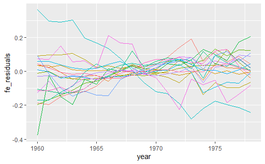

```r
library(dplyr)
library(ggplot2)
OECDGas <- OECDGas %>% mutate(fe_residuals = fe$residuals)
ggplot(data = OECDGas)+ geom_line(aes(x = year, y = fe_residuals, color=country), show.legend = FALSE)
```

It’s hard to see amidst all the squiggles, but some lines definitely do not look random. We can also take a look at the residual’s **autocorrelation function** to see they are indeed serially correlated:

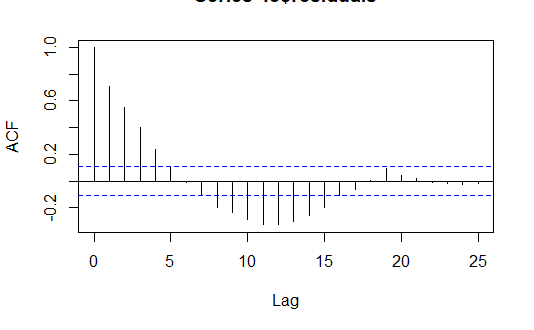

```r
acf(fe$residuals)
```

A statistical test may help persuade the reviewer. Let’s use a Durbin Whatson test to test for AR(1) serial correlation:

```r
pdwtest(fe)
```

```
    Durbin-Watson test for serial correlation in
    panel models

data:  gas ~ price + income + cars
DW = 0.57794, p-value < 2.2e-16
alternative hypothesis: serial correlation in idiosyncratic errors
```

The Durbin-Whatson test leads us to conclude that residuals are *not* independent, and that there *is* serial correlation between the residuals.

We could also have done a Breusch-Godfrey test. It tests exactly the same hypothesis (but allows residuals to follow AR processes of higher order, if that’s something we’re interested in doing)

```r
pbgtest(fe, order = 1)
```

```
    Breusch-Godfrey/Wooldridge test for serial
    correlation in panel models

data:  gas ~ price + income + cars
chisq = 170.25, df = 1, p-value < 2.2e-16
alternative hypothesis: serial correlation in idiosyncratic errors
```

The Breusch-Godfrey test also acuses serial correlation in the residuals. In short, both the Durbin-Whatson and the Breusch-Godrey test agree that residuals are serially correlated.

The implication is simple: Fixed Effects is compromised.

Here’s where the First Difference model comes in. As a first model to try after the residuals of the Fixed Effects model have proven to be serially correlated. The procedure is to run a FD model and test if its residuals are independent. This is done in the following code snippet.

```r
fd <- plm(gas ~ income + price + cars, data=OECDGas, model = 'fd')

pdwtest(fd)
```

```
    Durbin-Watson test for serial correlation in
    panel models

data:  gas ~ income + price + cars
DW = 2.3971, p-value = 0.9998
alternative hypothesis: serial correlation in idiosyncratic errors
```

With the FD model, the Durbin-Whatson test does not reject the hypothesis that residuals are independent.

So let’s look at the actual coefficients and, in particular, let’s compare them to those of the Fixed Effects model.

```r
stargazer(fe,
          fd,
          type='text',
          object.names = TRUE,
          model.names = FALSE,
          model.numbers = FALSE)
```

[output not shown]

```
=============================================================
                           Dependent variable:
             ------------------------------------------------
                                   gas
                        fe                      fd
-------------------------------------------------------------
price               -0.322***                -0.252***
                     (0.044)                  (0.031)

income               0.662***                0.242***
                     (0.073)                  (0.084)

cars                -0.640***                -0.656***
                     (0.030)                  (0.043)

Constant                                     0.020***
                                              (0.005)

-------------------------------------------------------------
Observations           342                      324
R2                    0.840                    0.469
Adjusted R2           0.830                    0.464
F Statistic  560.093*** (df = 3; 321) 94.218*** (df = 3; 320)
=============================================================
Note:                             *p<0.1; **p<0.05; ***p<0.01
```

Price is still negative and income is sill positive, both as expected. But both have changed considerably! In particular, the the demand for gas is not as sensitive to price as previously estimated. Likewise, an increase in income has a much smaller impact on gas consumption than anticipated by the FE model.